# 2Submission_Metanalysis

Esteban Agudo

2023-05-18

```r
library(dplyr)
library(tidyr)
library(ggplot2)
library(metafor)
library(stringr)
library(cowplot)
library(gridExtra)
library(lemon)
library(lme4)
library(metaviz)
library(lemon)
library("rnaturalearth")
library("rnaturalearthdata")
library("sf")
library("ggspatial")
library(sjPlot)
library(reactable)
library(ggpubr)
library(extrafont)
library(scales)
library(fishualize)
library(xlsx)
library(ggpubr)
library("rnaturalearth")
library("rnaturalearthdata")
library("sf")
library("ggspatial")


#loadfonts(device="win")
colour.palette <- c("#332288", "red3", "#E69F00", "#117733", "#56B4E9","#E69F00",  "#CC79A7", "#D55E00", "#0072B2", "#F0E442", "#CC6677")
```

```r
data<-read.csv(file="data.csv", header=TRUE)
str(data)
```

```
## 'data.frame':    160 obs. of  44 variables:
##  $ Authors               : chr  "Allan et al., " "Allan et al., " "Allan et al., " "Allan et al., " ...
##  $ Year                  : int  2013 2015 2017 2017 2017 2012 2012 2012 2012 2012 ...
##  $ Title                 : chr  "Elevated CO2 affects predator-prey interaction through altered performance." "Feeling the heat: the effect of acute temperature changes on predators-prey interaction in coral reef fish." "Warming has a greater effect than elevated CO2 on predator-prey interactions…
##  $ Journal               : chr  "Plos One" "Conservation physiology" "Procedings of the Royal Society B: Biological Science" "Procedings of the Royal Society B: Biological Science" ...
##  $ Tax_Group             : chr  "Fish" "Fish" "Fish" "Fish" ...
##  $ Tax_Group_specific    : chr  "Fishes" "Fishes" "Fishes" "Fishes" ...
##  $ Consumer_Sp           : chr  "Pseudochromys fuscus" "Pseudochromis fuscus" "Pseudochromis fuscus" "Pseudochromis fuscus" ...
##  $ TrophicLevel          : chr  "Carnivore" "Carnivore" "Carnivore" "Carnivore" ...
##  $ Prey_Sp               : chr  "Pomacentrus amboinensis" "Pomacentrus wardi" "Pomacentrus wardi" "Pomacentrus wardi" ...
##  $ Habitat               : chr  "Coral reef" "Coral reef" "Coral reef" "Coral reef" ...
##  $ Country               : chr  "Australia GBR" "Australia" "Australia" "Australia" ...
##  $ Weather               : chr  "Tropical" "Tropical" "Tropical" "Tropical" ...
##  $ Interaction           : chr  "Predation" "Predation" "Predation" "Predation" ...
##  $ Treatment             : chr  "Acidification" "Warming" "Warming" "Acidification" ...
```

[output cut: 30 more lines]

#Exploratory values Number of experiments per treatment and ecological interaction

```r
#Number experiments
data %>% tally
```

```
##     n
## 1 160
```

```r
#Number of studies
data %>% distinct(Title)%>% tally
```

```
##    n
## 1 43
```

```r
#Number experiments per treatment
data %>%
  group_by(Treatment)%>%tally
```

```
## # A tibble: 3 × 2
##   Treatment                 n
##   <chr>                 <int>
## 1 Acidification            56
## 2 Warming                  81
## 3 Warming+Acidification    23
```

```r
#Number studies per treatment
data %>%
  group_by(Treatment)%>%distinct(Title)%>%tally
```

```
## # A tibble: 3 × 2
##   Treatment                 n
##   <chr>                 <int>
## 1 Acidification            25
## 2 Warming                  29
## 3 Warming+Acidification    12
```

```r
#Number experiments per taxonomic group
data %>%
  group_by(Tax_Group_specific)%>%distinct(Title)%>%
tally
```

```
## # A tibble: 6 × 2
##   Tax_Group_specific     n
##   <chr>              <int>
## 1 Amphipods              3
## 2 Crabs                  7
## 3 Fishes                11
## 4 Gastropod              9
## 5 Sea stars              8
## 6 Sea urchins           10
```

```r
data %>%
  group_by(Tax_Group)%>%tally
```

```
## # A tibble: 4 × 2
##   Tax_Group          n
##   <chr>          <int>
## 1 "Crustaceans "    24
## 2 "Echinoderm"      75
## 3 "Fish"            38
## 4 "Gastropods"      23
```

```r
#Number studies per treatment and tax group
ts<-data %>%
  group_by(Treatment, Tax_Group)%>%distinct(Title)%>%tally

te<-data %>%
  group_by(Treatment, Tax_Group)%>%tally

cbind(ts, te$n)
```

```
## # A tibble: 12 × 4
## # Groups:   Treatment [3]
##    Treatment             Tax_Group          n  ...4
##    <chr>                 <chr>          <int> <int>
##  1 Acidification         "Crustaceans "     6     8
##  2 Acidification         "Echinoderm"       9    23
##  3 Acidification         "Fish"             7    15
##  4 Acidification         "Gastropods"       7    10
##  5 Warming               "Crustaceans "     6    11
##  6 Warming               "Echinoderm"      12    42
##  7 Warming               "Fish"             8    19
##  8 Warming               "Gastropods"       5     9
##  9 Warming+Acidification "Crustaceans "     3     5
## 10 Warming+Acidification "Echinoderm"       5    10
## 11 Warming+Acidification "Fish"             4     4
## 12 Warming+Acidification "Gastropods"       2     4
```

```r
#Number of studies and experimetns in the tropics and temperate
data %>%
  group_by(Weather)%>%distinct(Title)%>%tally
```

```
## # A tibble: 2 × 2
##   Weather       n
##   <chr>     <int>
## 1 Temperate    32
## 2 Tropical     11
```

```r
data %>%
  group_by(Weather)%>%tally
```

```
## # A tibble: 2 × 2
##   Weather       n
##   <chr>     <int>
## 1 Temperate   118
## 2 Tropical     42
```

```r
#Number of studies and experiments per habitat
data %>%
  group_by(Habitat)%>%distinct(Title)%>%tally
```

```
## # A tibble: 4 × 2
##   Habitat         n
##   <chr>       <int>
## 1 Coral reef     10
## 2 Kelp forest     2
## 3 Rocky reef     25
## 4 Rocky shore     6
```

```r
data %>%
  group_by(Habitat)%>%tally
```

```
## # A tibble: 4 × 2
##   Habitat         n
##   <chr>       <int>
## 1 Coral reef     38
## 2 Kelp forest     4
## 3 Rocky reef     94
## 4 Rocky shore    24
```

```r
#Number of studies and experiments considering taxonomic group and interaction
data %>%
  group_by(Treatment, Interaction)%>%distinct(Title)%>%tally
```

```
## # A tibble: 6 × 3
## # Groups:   Treatment [3]
##   Treatment             Interaction     n
##   <chr>                 <chr>       <int>
## 1 Acidification         Herbivory       9
## 2 Acidification         Predation      16
## 3 Warming               Herbivory      15
## 4 Warming               Predation      14
## 5 Warming+Acidification Herbivory       6
## 6 Warming+Acidification Predation       6
```

```r
data %>%
  group_by(Treatment, Interaction)%>%tally
```

```
## # A tibble: 6 × 3
## # Groups:   Treatment [3]
##   Treatment             Interaction     n
##   <chr>                 <chr>       <int>
## 1 Acidification         Herbivory      22
## 2 Acidification         Predation      34
## 3 Warming               Herbivory      47
## 4 Warming               Predation      34
## 5 Warming+Acidification Herbivory      16
## 6 Warming+Acidification Predation       7
```

```r
#Number of studies and experiments considering stressor, and taxonomic group specific
study<-data %>%
  group_by(Treatment, Tax_Group_specific)%>%distinct(Title)%>%tally %>% print(n=27)
```

```
## # A tibble: 18 × 3
## # Groups:   Treatment [3]
##    Treatment             Tax_Group_specific     n
##    <chr>                 <chr>              <int>
##  1 Acidification         Amphipods              2
##  2 Acidification         Crabs                  4
##  3 Acidification         Fishes                 7
##  4 Acidification         Gastropod              7
##  5 Acidification         Sea stars              4
##  6 Acidification         Sea urchins            5
##  7 Warming               Amphipods              2
##  8 Warming               Crabs                  5
##  9 Warming               Fishes                 8
## 10 Warming               Gastropod              5
## 11 Warming               Sea stars              5
## 12 Warming               Sea urchins            7
## 13 Warming+Acidification Amphipods              1
## 14 Warming+Acidification Crabs                  2
## 15 Warming+Acidification Fishes                 4
## 16 Warming+Acidification Gastropod              2
## 17 Warming+Acidification Sea stars              1
## 18 Warming+Acidification Sea urchins            4
```

```r
exp<-data %>%
  group_by(Treatment, Tax_Group_specific)%>%tally %>% print(n=27)
```

```
## # A tibble: 18 × 3
## # Groups:   Treatment [3]
##    Treatment             Tax_Group_specific     n
##    <chr>                 <chr>              <int>
##  1 Acidification         Amphipods              2
##  2 Acidification         Crabs                  6
##  3 Acidification         Fishes                15
##  4 Acidification         Gastropod             10
##  5 Acidification         Sea stars              9
##  6 Acidification         Sea urchins           14
##  7 Warming               Amphipods              4
##  8 Warming               Crabs                  9
##  9 Warming               Fishes                19
## 10 Warming               Gastropod              9
## 11 Warming               Sea stars             17
## 12 Warming               Sea urchins           23
## 13 Warming+Acidification Amphipods              3
## 14 Warming+Acidification Crabs                  2
## 15 Warming+Acidification Fishes                 4
## 16 Warming+Acidification Gastropod              4
## 17 Warming+Acidification Sea stars              4
## 18 Warming+Acidification Sea urchins            6
```

```r
cbind(study, exp$n) #Studies and experiments considering taxonomic group and stressor
```

```
## # A tibble: 18 × 4
## # Groups:   Treatment [3]
##    Treatment             Tax_Group_specific     n  ...4
##    <chr>                 <chr>              <int> <int>
##  1 Acidification         Amphipods              2     2
##  2 Acidification         Crabs                  4     6
##  3 Acidification         Fishes                 7    15
##  4 Acidification         Gastropod              7    10
##  5 Acidification         Sea stars              4     9
##  6 Acidification         Sea urchins            5    14
##  7 Warming               Amphipods              2     4
##  8 Warming               Crabs                  5     9
##  9 Warming               Fishes                 8    19
## 10 Warming               Gastropod              5     9
## 11 Warming               Sea stars              5    17
## 12 Warming               Sea urchins            7    23
## 13 Warming+Acidification Amphipods              1     3
## 14 Warming+Acidification Crabs                  2     2
## 15 Warming+Acidification Fishes                 4     4
## 16 Warming+Acidification Gastropod              2     4
## 17 Warming+Acidification Sea stars              1     4
## 18 Warming+Acidification Sea urchins            4     6
```

```r
significance <-data %>%
  select(Treatment, Significance) %>%
  group_by(Treatment, Significance) %>%
  tally()

significance
```

```
## # A tibble: 7 × 3
## # Groups:   Treatment [3]
##   Treatment             Significance        n
##   <chr>                 <chr>           <int>
## 1 Acidification         Non significant    32
## 2 Acidification         Significant        24
## 3 Warming               Non significant    20
## 4 Warming               Not tested         22
## 5 Warming               Significant        39
## 6 Warming+Acidification Non significant     7
## 7 Warming+Acidification Significant        16
```

```r
data_effect<-data %>%
  filter(Significance=="Significant")%>%
  select(Treatment, #Tax_Group, Significance,
         Type_Effect) %>%
  group_by(Treatment, #Tax_Group, Significance,
           Type_Effect)%>%
tally()

# 54, 79, 21

data_effect
```

```
## # A tibble: 6 × 3
## # Groups:   Treatment [3]
##   Treatment             Type_Effect     n
##   <chr>                 <chr>       <int>
## 1 Acidification         Negative       11
## 2 Acidification         Positive       13
## 3 Warming               Negative        6
## 4 Warming               Positive       33
## 5 Warming+Acidification Negative        3
## 6 Warming+Acidification Positive       13
```

```r
data_tax<-data%>%
  filter(Significance=="Significant")%>%
  select(Treatment, Tax_Group, Type_Effect) %>%
  group_by(Treatment, Tax_Group, Type_Effect)%>%
tally()

data_tax
```

```
## # A tibble: 19 × 4
## # Groups:   Treatment, Tax_Group [12]
##    Treatment             Tax_Group      Type_Effect     n
##    <chr>                 <chr>          <chr>       <int>
##  1 Acidification         "Crustaceans " Negative        5
##  2 Acidification         "Crustaceans " Positive        1
##  3 Acidification         "Echinoderm"   Negative        6
##  4 Acidification         "Echinoderm"   Positive        3
##  5 Acidification         "Fish"         Positive        4
##  6 Acidification         "Gastropods"   Positive        5
##  7 Warming               "Crustaceans " Negative        2
##  8 Warming               "Crustaceans " Positive        4
##  9 Warming               "Echinoderm"   Negative        3
## 10 Warming               "Echinoderm"   Positive       14
## 11 Warming               "Fish"         Positive       12
## 12 Warming               "Gastropods"   Negative        1
## 13 Warming               "Gastropods"   Positive        3
## 14 Warming+Acidification "Crustaceans " Negative        2
## 15 Warming+Acidification "Crustaceans " Positive        3
## 16 Warming+Acidification "Echinoderm"   Negative        1
## 17 Warming+Acidification "Echinoderm"   Positive        3
## 18 Warming+Acidification "Fish"         Positive        4
## 19 Warming+Acidification "Gastropods"   Positive        3
```

Transform into factors

```r
data$Tax_Group<-factor(data$Tax_Group)
data$Tax_Group_specific<-factor(data$Tax_Group_specific)
data$Treatment<-factor(data$Treatment)
data$Interaction<-factor(data$Interaction)
data$Habitat<-factor(data$Habitat)

#Ordering some data
data$Significance<-factor(data$Significance, levels=c("Significant", "Non significant", "Not tested"))
```

# Rol of Temperature and acidification on feeding rates

Lets start by normalizing

```r
data<-escalc("ROM", m2i = Control_Mean       #log transformed ratio of mean
 , sd2i = Control_SD
 , n2i =Control_n
 , m1i= Treatment_Mean
, sd1i = Treatment_SD
, n1i = Treatment_n
,  data = data, digits = 8)
```

# Histogram of effects

```r
head(data)
```

```
##
##          Authors Year
## 1 Allan et al.,  2013
## 2 Allan et al.,  2015
## 3 Allan et al.,  2017
## 4 Allan et al.,  2017
## 5 Allan et al.,  2017
## 6 Amaral et al., 2012
##                                                                                                         Title
## 1                                 Elevated CO2 affects predator-prey interaction through altered performance.
## 2 Feeling the heat: the effect of acute temperature changes on predators-prey interaction in coral reef fish.
## 3             Warming has a greater effect than elevated CO2 on predator-prey interactions in coral reef fish
## 4             Warming has a greater effect than elevated CO2 on predator-prey interactions in coral reef fish
## 5             Warming has a greater effect than elevated CO2 on predator-prey interactions in coral reef fish
## 6                                             Effect of estuarine acidification on predator-prey interaction
```

[output cut: 63 more lines]

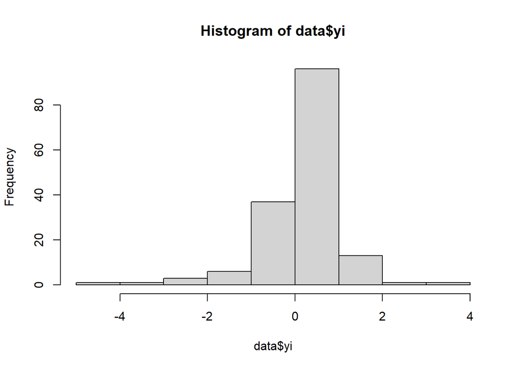

```r
hist(data$yi)
```

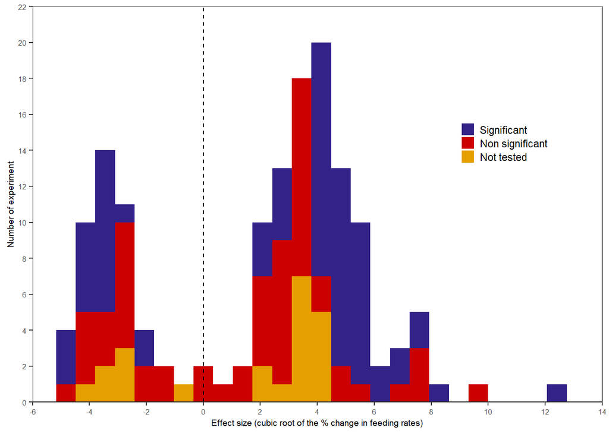

```r
data<-data %>%
  mutate(Percentage_Effect=(100*(exp(yi)-1)))



data_histogram<-data %>%
  filter(Significance=="Significant")


data_histogram_table<-data %>%
  filter(Significance=="Significant")%>%
  select(Treatment, Percentage_Effect) %>%
  group_by(Treatment) %>%
  summarize(min=min(abs(Percentage_Effect)), mean=abs((Percentage_Effect)), max=max(abs(Percentage_Effect)), sd=sd(abs(Percentage_Effect)))
data_warm_hist<-data_histogram %>%
  filter(Treatment=="Warming")

data_acid_hist<-data_histogram %>%
  filter(Treatment=="Acidification")

data_acid_warm_hist<-data_histogram %>%
  filter(Treatment=="Warming+Acidification")

histogram_multistressor<-ggplot(data, aes(x=sign(Percentage_Effect)*(abs(Percentage_Effect))^(1/3)), color=Significance) +    geom_histogram(data=data, aes(fill=Significance))+
  theme_bw()+xlab("Effect size (cubic root of the % change in feeding rates)")+ylab("Number of experiment")+
    geom_vline(xintercept=0, linetype="dashed")+
  theme(axis.title = element_text(size = 7), axis.text=element_text(size=6),  panel.grid.major = element_blank(), panel.grid.minor = element_blank())+
    geom_vline(xintercept=0, linetype="dashed")+
  scale_y_continuous(breaks=seq(0, 22, 2), limits = c(0, 22), expand=c(0, 0))+
  scale_x_continuous(breaks=seq(-6, 14, 2), limits = c(-6, 14), expand=c(0, 0))+
  theme(legend.position = c(.75, .60),
    legend.direction = "vertical",
    legend.justification = c("left", "bottom"),
    legend.box.just = "left",
    legend.margin = margin(1, 1, 1, 1),
    legend.spacing.y = unit(0.05, "cm"),
      legend.text = element_text(size = 8.5, family = "Arial"),
  legend.title=element_text(size=8.5, family = "Arial"),
   legend.key.size = unit(0.4, "cm"),
      legend.key.height = unit(0.4, "cm"))+
   scale_fill_manual(values=colour.palette)+
  labs(fill=NULL)

histogram_multistressor
```

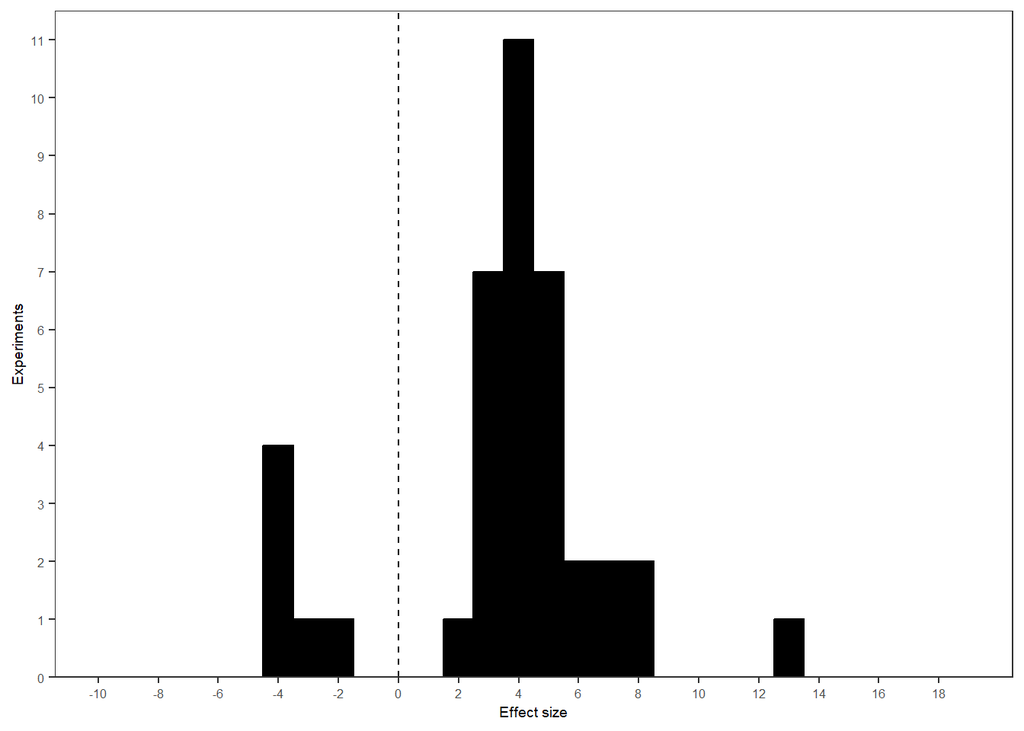

```r
#hist_percentage<-

#cubic root of percentage effect #can't used sqrt or log because I have negative values

#cubic root of warming effect
hist_warming<-ggplot(data_warm_hist, aes(x=sign(Percentage_Effect)*(abs(Percentage_Effect))^(1/3))) +  #can't used sqrt or log because I have negative values
  geom_histogram(color="black", fill="black")+
  theme_bw()+xlab("Effect size")+
  ylab("Experiments")+
  theme(axis.title = element_text(size = 7), axis.text=element_text(size=6), panel.grid.major = element_blank(), panel.grid.minor = element_blank())+
    geom_vline(xintercept=0, linetype="dashed")+
    scale_x_continuous(breaks=seq(-10, 19, 2), limits=c(-10, 19))+
    scale_y_continuous(breaks=seq(0, 11.5, 1), limits = c(0, 11.5), expand=c(0, 0))

hist_warming
```

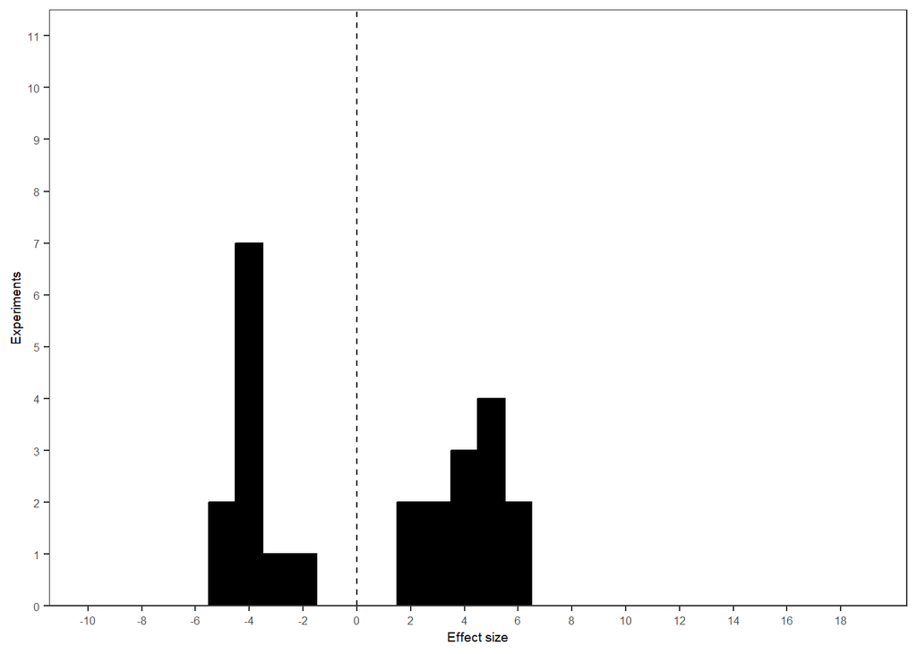

```r
#cubic root of acidification effect
hist_acid<-ggplot(data_acid_hist, aes(x=sign(Percentage_Effect)*(abs(Percentage_Effect))^(1/3))) +  geom_histogram(color="black", fill="black")+
  theme_bw()+xlab("Effect size")+
  ylab("Experiments")+
   theme(axis.title = element_text(size = 7), axis.text=element_text(size=6),  panel.grid.major = element_blank(), panel.grid.minor = element_blank())+
    geom_vline(xintercept=0, linetype="dashed") +
  scale_x_continuous(breaks=seq(-10, 19, 2), limits=c(-10, 19))+
   # scale_x_continuous(breaks=seq(-10, 20, 2))+
    scale_y_continuous(breaks=seq(0, 11.5, 1), limits = c(0, 11.5), expand=c(0, 0))

hist_acid
```

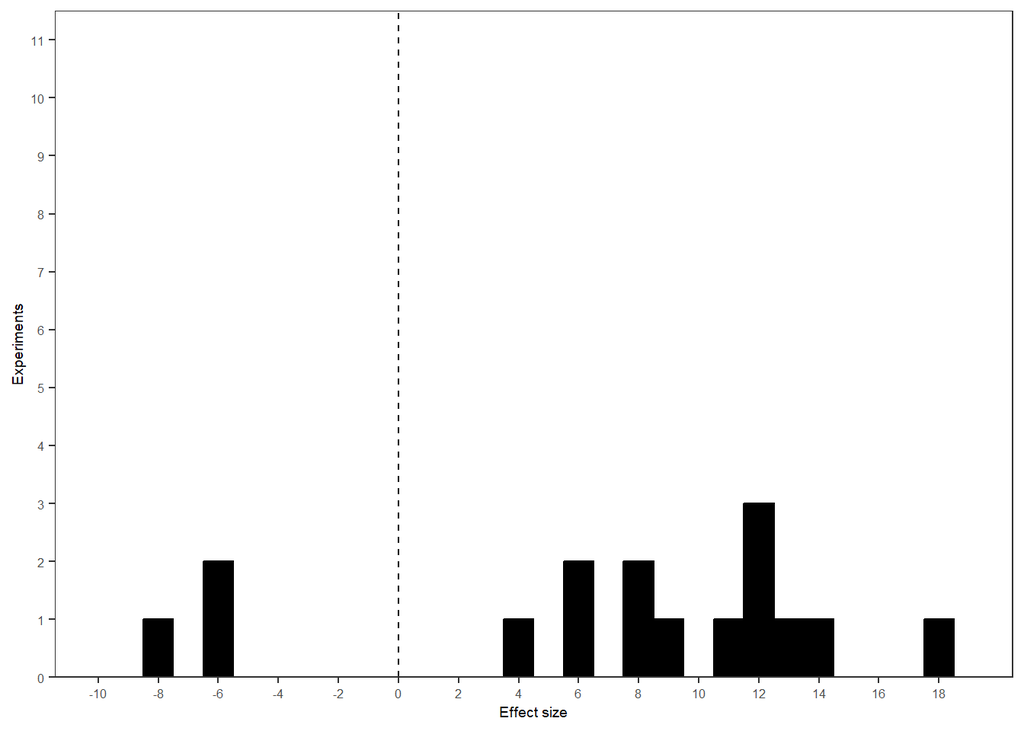

```r
#sqrt of percentage effect with warming + acidification
hist_acid_warm<-ggplot(data_acid_warm_hist, aes(x=sign(Percentage_Effect)*sqrt(abs(Percentage_Effect)))) +  #can't used sqrt or log because I have negative values
  geom_histogram(color="black", fill="black")+
  theme_bw()+xlab("Effect size")+
  ylab("Experiments")+
   theme(axis.title = element_text(size = 7), axis.text=element_text(size=6), panel.grid.major = element_blank(), panel.grid.minor = element_blank())+
    geom_vline(xintercept=0, linetype="dashed")+
   scale_x_continuous(breaks=seq(-10, 19, 2), limits=c(-10, 19))+
    scale_y_continuous(breaks=seq(0, 11.5, 1), limits = c(0, 11.5), expand=c(0, 0))

hist_acid_warm
```

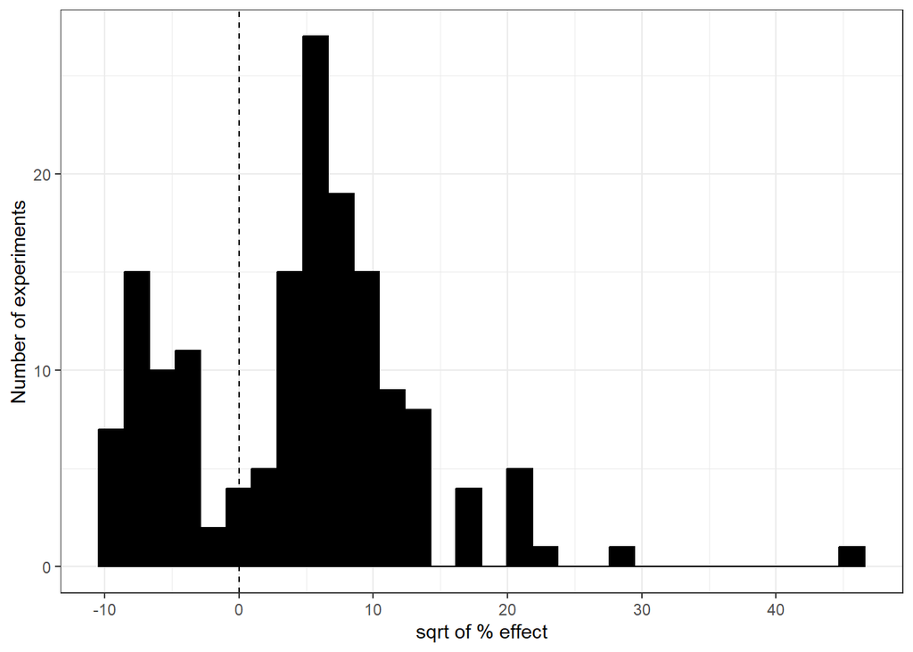

```r
#Compared with sqrt data including non significant results of both warming and acidificaiton
ggplot(data, aes(x=sign(Percentage_Effect)*sqrt(abs(Percentage_Effect))))+
  geom_histogram(color="black", fill="black")+
  theme_bw()+xlab("sqrt of % effect")+ylab("Number of experiments")+
    geom_vline(xintercept=0, linetype="dashed")
```

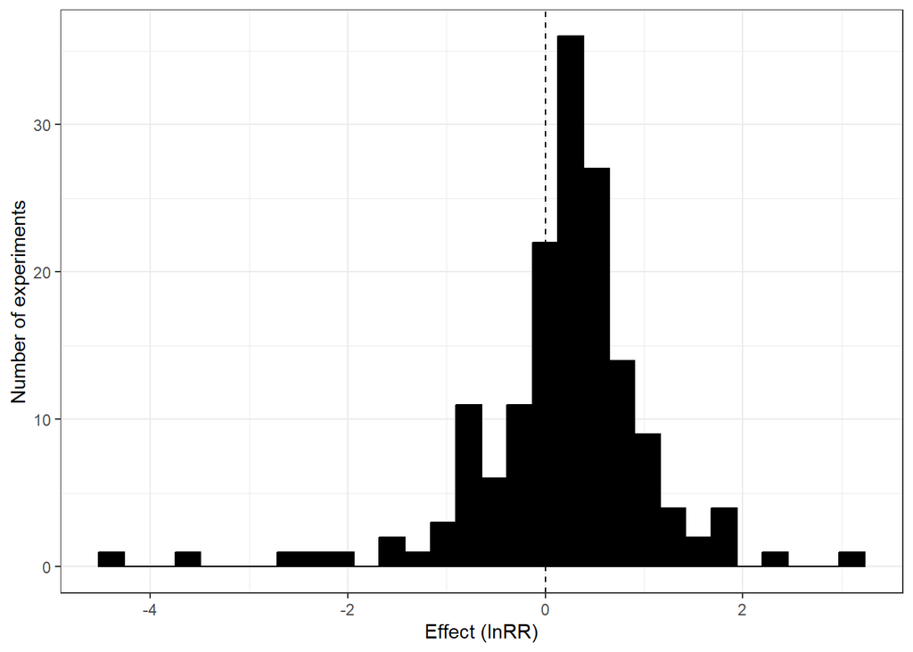

```r
#hist_RatioEffect<-
# logRR of both warming and acidification
ggplot(data, aes(x=yi)) +
  geom_histogram(color="black", fill="black")+
  theme_bw()+xlab("Effect (lnRR)")+ylab("Number of experiments")+
  geom_vline(xintercept=0, linetype="dashed")+
  stat_function(fun = dnorm, args = list(mean = mean(data$Percentage_Effect), sd = sd(data$Percentage_Effect)))
```

```r
#hist_RatioEffect
```

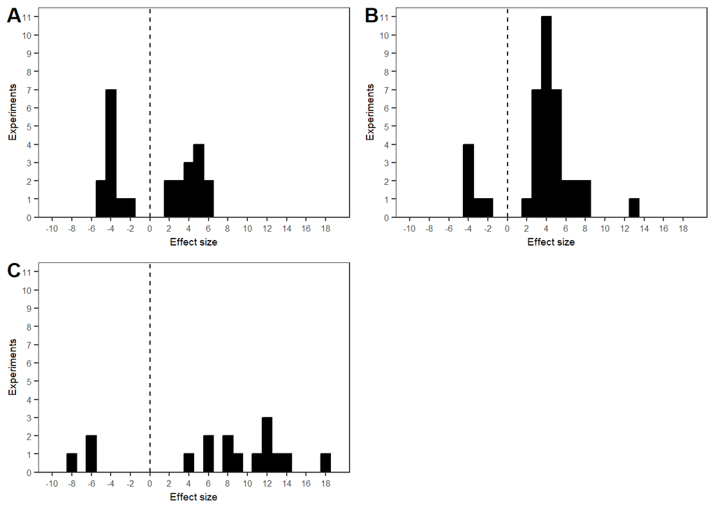

```r
hist_comb <- ggarrange(hist_acid, hist_warming, hist_acid_warm
,                  labels = c("A", "B", "C"),
                    ncol = 2, nrow = 2)
hist_comb
```

```r
hist_comb_multistressor <- ggarrange(histogram_multistressor,
                  ggarrange(hist_acid, hist_warming, hist_acid_warm, ncol=3, labels=c("B", "C", "D")),
                  labels = c("A"),
                    nrow = 2)
```

[output not shown]

[output not shown]

[output cut: 34 more lines]

[output not shown]

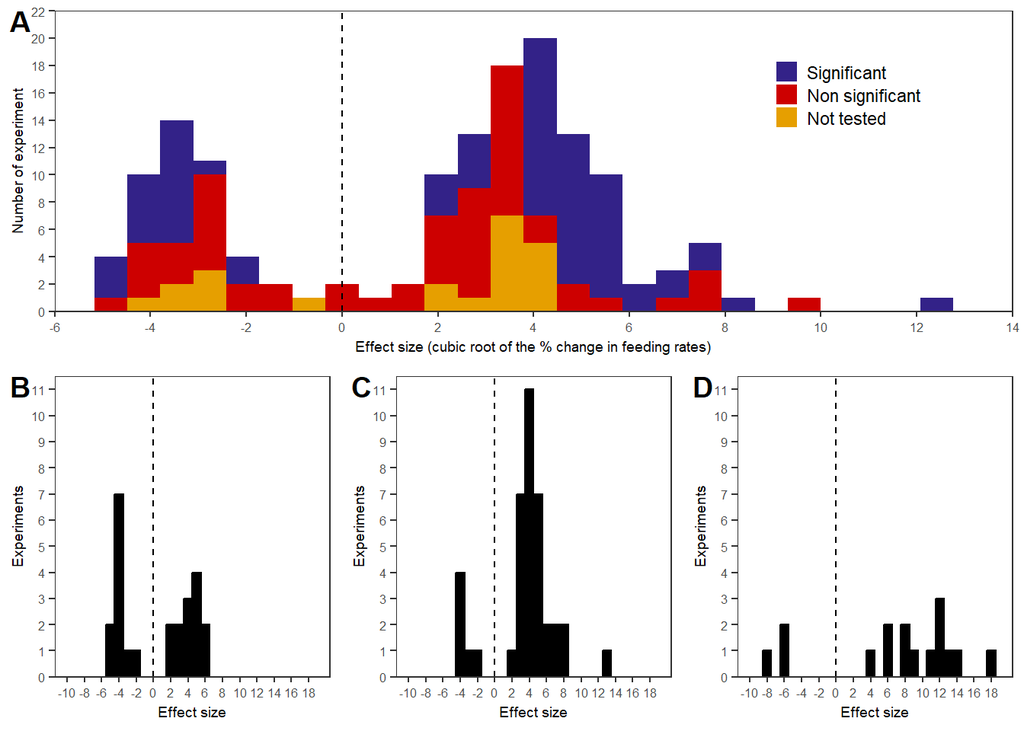

```r
hist_comb_multistressor
```

```r
png("Figures/Fig2_HistogramEffects.png", width=15, height=14, units="cm", res=300)
print(hist_comb)
dev.off()
```

```r
png("Figures/Fig2_HistogramMultistressor.png", width=15, height=14, units="cm", res=300)
print(histogram_multistressor)
dev.off()
```

```r
png("Figures/Fig2_HistogramCombineMultistressor.png", width=15, height=14, units="cm", res=300)
print(hist_comb_multistressor)
dev.off()
```

```r
write.xlsx(data, file = "data_effects.xlsx",
   sheetName = "data_new", append = TRUE)
```

## Metaregressions

```r
#model considering only treatment
model1<- rma.mv(yi,vi, mods =~Treatment-1, random=~1|Title,  method = "REML", knha=TRUE, data = data)
summary(model1)
```

```
##
## Multivariate Meta-Analysis Model (k = 159; method: REML)
##
##    logLik   Deviance        AIC        BIC       AICc
## -323.7996   647.5993   655.5993   667.7987   655.8642
##
## Variance Components:
##
##             estim    sqrt  nlvls  fixed  factor
## sigma^2    0.3273  0.5721     43     no   Title
##
## Test for Residual Heterogeneity:
## QE(df = 156) = 1453.7466, p-val < .0001
##
## Test of Moderators (coefficients 1:3):
## QM(df = 3) = 15.7396, p-val = 0.0013
##
## Model Results:
##
##                                 estimate      se    zval    pval    ci.lb
## TreatmentAcidification            0.0854  0.1013  0.8431  0.3992  -0.1131
## TreatmentWarming                  0.2718  0.0985  2.7585  0.0058   0.0787
## TreatmentWarming+Acidification    0.3109  0.1078  2.8839  0.0039   0.0996
##                                  ci.ub
## TreatmentAcidification          0.2839
## TreatmentWarming                0.4650  **
## TreatmentWarming+Acidification  0.5222  **
##
## ---
## Signif. codes:  0 '***' 0.001 '**' 0.01 '*' 0.05 '.' 0.1 ' ' 1
```

```r
#model considering treatment and interaction
model2<- rma.mv(yi,vi, mods =~Treatment:Interaction-1, random=~1|Title,  method = "REML", knha=TRUE, data = data)
 summary(model2)
```

```
##
## Multivariate Meta-Analysis Model (k = 159; method: REML)
##
##    logLik   Deviance        AIC        BIC       AICc
## -315.0198   630.0396   644.0396   665.2527   644.8120
##
## Variance Components:
##
##             estim    sqrt  nlvls  fixed  factor
## sigma^2    0.3162  0.5623     43     no   Title
##
## Test for Residual Heterogeneity:
## QE(df = 153) = 1264.5840, p-val < .0001
##
## Test of Moderators (coefficients 1:6):
## QM(df = 6) = 32.3306, p-val < .0001
##
## Model Results:
##
##                                                      estimate      se     zval
## TreatmentAcidification:InteractionHerbivory            0.3643  0.1489   2.4472
## TreatmentWarming:InteractionHerbivory                  0.3281  0.1391   2.3595
## TreatmentWarming+Acidification:InteractionHerbivory    0.4237  0.1510   2.8063
## TreatmentAcidification:InteractionPredation           -0.1686  0.1351  -1.2480
## TreatmentWarming:InteractionPredation                  0.3329  0.1389   2.3963
## TreatmentWarming+Acidification:InteractionPredation    0.2799  0.1543   1.8146
##                                                        pval    ci.lb   ci.ub
## TreatmentAcidification:InteractionHerbivory          0.0144   0.0725  0.6561
## TreatmentWarming:InteractionHerbivory                0.0183   0.0556  0.6007
## TreatmentWarming+Acidification:InteractionHerbivory  0.0050   0.1278  0.7197
## TreatmentAcidification:InteractionPredation          0.2120  -0.4333  0.0962
## TreatmentWarming:InteractionPredation                0.0166   0.0606  0.6052
## TreatmentWarming+Acidification:InteractionPredation  0.0696  -0.0224  0.5823
##
## TreatmentAcidification:InteractionHerbivory           *
## TreatmentWarming:InteractionHerbivory                 *
## TreatmentWarming+Acidification:InteractionHerbivory  **
## TreatmentAcidification:InteractionPredation
## TreatmentWarming:InteractionPredation                 *
## TreatmentWarming+Acidification:InteractionPredation   .
##
## ---
## Signif. codes:  0 '***' 0.001 '**' 0.01 '*' 0.05 '.' 0.1 ' ' 1
```

```r
#model considering treatment, interaction, taxonomic group
model3<- rma.mv(yi,vi, mods =~Treatment:Interaction:Tax_Group-1, random=~1|Title,  method = "REML", knha=TRUE, data = data)
summary(model3)
```

```
##
## Multivariate Meta-Analysis Model (k = 159; method: REML)
##
##    logLik   Deviance        AIC        BIC       AICc
## -277.7873   555.5746   601.5746   668.7341   611.3445
##
## Variance Components:
##
##             estim    sqrt  nlvls  fixed  factor
## sigma^2    0.2495  0.4995     43     no   Title
##
## Test for Residual Heterogeneity:
## QE(df = 137) = 811.4662, p-val < .0001
##
## Test of Moderators (coefficients 1:22):
## QM(df = 22) = 108.7319, p-val < .0001
##
## Model Results:
##
##                                                                            estimate
## TreatmentAcidification:InteractionHerbivory:Tax_GroupCrustaceans             0.1421
## TreatmentWarming:InteractionHerbivory:Tax_GroupCrustaceans                   0.2797
## TreatmentWarming+Acidification:InteractionHerbivory:Tax_GroupCrustaceans     0.5095
## TreatmentAcidification:InteractionPredation:Tax_GroupCrustaceans            -0.9137
## TreatmentWarming:InteractionPredation:Tax_GroupCrustaceans                  -0.0348
## TreatmentWarming+Acidification:InteractionPredation:Tax_GroupCrustaceans    -0.5823
## TreatmentAcidification:InteractionHerbivory:Tax_GroupEchinoderm              0.2436
## TreatmentWarming:InteractionHerbivory:Tax_GroupEchinoderm                    0.2974
## TreatmentWarming+Acidification:InteractionHerbivory:Tax_GroupEchinoderm      0.3228
## TreatmentAcidification:InteractionPredation:Tax_GroupEchinoderm             -0.7501
## TreatmentWarming:InteractionPredation:Tax_GroupEchinoderm                    0.0142
## TreatmentAcidification:InteractionHerbivory:Tax_GroupFish                    0.6191
## TreatmentWarming:InteractionHerbivory:Tax_GroupFish                          0.4287
## TreatmentAcidification:InteractionPredation:Tax_GroupFish                    0.3015
## TreatmentWarming:InteractionPredation:Tax_GroupFish                          0.6637
## TreatmentWarming+Acidification:InteractionPredation:Tax_GroupFish            1.1084
## TreatmentAcidification:InteractionHerbivory:Tax_GroupGastropods              0.9751
## TreatmentWarming:InteractionHerbivory:Tax_GroupGastropods                    0.5529
## TreatmentWarming+Acidification:InteractionHerbivory:Tax_GroupGastropods      0.7279
## TreatmentAcidification:InteractionPredation:Tax_GroupGastropods              0.1646
```

[output cut: 128 more lines]

```
## TreatmentWarming:InteractionPredation:Tax_GroupEchinoderm
## TreatmentAcidification:InteractionHerbivory:Tax_GroupFish                   **
## TreatmentWarming:InteractionHerbivory:Tax_GroupFish
## TreatmentAcidification:InteractionPredation:Tax_GroupFish
## TreatmentWarming:InteractionPredation:Tax_GroupFish                         **
## TreatmentWarming+Acidification:InteractionPredation:Tax_GroupFish          ***
## TreatmentAcidification:InteractionHerbivory:Tax_GroupGastropods            ***
## TreatmentWarming:InteractionHerbivory:Tax_GroupGastropods                    *
## TreatmentWarming+Acidification:InteractionHerbivory:Tax_GroupGastropods     **
## TreatmentAcidification:InteractionPredation:Tax_GroupGastropods
## TreatmentWarming:InteractionPredation:Tax_GroupGastropods
## TreatmentWarming+Acidification:InteractionPredation:Tax_GroupGastropods
##
## ---
## Signif. codes:  0 '***' 0.001 '**' 0.01 '*' 0.05 '.' 0.1 ' ' 1
```

```r
#model considering treatment, Weather
model4<- rma.mv(yi,vi, mods =~Treatment*Weather-1, random=~1|Title,  method = "REML", knha=TRUE, data = data)
summary(model4)
```

```
##
## Multivariate Meta-Analysis Model (k = 159; method: REML)
##
##    logLik   Deviance        AIC        BIC       AICc
## -320.0920   640.1841   654.1841   675.3971   654.9565
##
## Variance Components:
##
##             estim    sqrt  nlvls  fixed  factor
## sigma^2    0.3294  0.5739     43     no   Title
##
## Test for Residual Heterogeneity:
## QE(df = 153) = 1409.9570, p-val < .0001
##
## Test of Moderators (coefficients 1:6):
## QM(df = 6) = 21.9747, p-val = 0.0012
##
## Model Results:
##
##                                                 estimate      se     zval
## TreatmentAcidification                           -0.0272  0.1187  -0.2290
## TreatmentWarming                                  0.2448  0.1125   2.1756
## TreatmentWarming+Acidification                    0.1979  0.1268   1.5611
## WeatherTropical                                   0.3939  0.2324   1.6946
## TreatmentWarming:WeatherTropical                 -0.2755  0.1508  -1.8263
## TreatmentWarming+Acidification:WeatherTropical   -0.0040  0.1508  -0.0268
##                                                   pval    ci.lb   ci.ub
## TreatmentAcidification                          0.8189  -0.2599  0.2055
## TreatmentWarming                                0.0296   0.0243  0.4654  *
## TreatmentWarming+Acidification                  0.1185  -0.0506  0.4463
## WeatherTropical                                 0.0902  -0.0617  0.8494  .
## TreatmentWarming:WeatherTropical                0.0678  -0.5711  0.0202  .
## TreatmentWarming+Acidification:WeatherTropical  0.9786  -0.2996  0.2915
##
## ---
## Signif. codes:  0 '***' 0.001 '**' 0.01 '*' 0.05 '.' 0.1 ' ' 1
```

```r
#model considering stressor and taxonomic group. For this I am filtering groups that have fewer than 4 and a single study on kelps with two experiments
levels(data$Treatment)
```

```
## [1] "Acidification"         "Warming"               "Warming+Acidification"
```

```r
#data<-data %>%
# filter(!(Treatment=='Acidification' & Tax_Group_specific=='Amphipods')) %>%
  #filter(!(Treatment=='Warming+Acidification' & Tax_Group_specific=='Amphipods')) %>%
  #filter(!(Treatment=='Warming+Acidification' & Tax_Group_specific=='Sea urchins')) %>%
 # filter(!(Treatment=='Warming+Acidification' & Tax_Group_specific=='Crabs')) %>%
  #filter(Temp_variation<11)
  #filter(!(Habitat=="Kelp forest"))%>%
  #filter(!ExpTreatment=="Prey")
  #filter(ExpTreatment=="Both")
 #filter(yi>-3) %>%
 #filter(yi<1.5)

# We did several filter to eliminate the studies which have a larger effect and prove this were not determine the significance of results by their own.

#model 7-> Comparing general taxonomic group
model7<- rma.mv(yi,vi, mods =~Treatment:Tax_Group-1, random=~1|Title,  method = "REML", knha=TRUE, data = data)
summary(model7)
```

```
##
## Multivariate Meta-Analysis Model (k = 159; method: REML)
##
##    logLik   Deviance        AIC        BIC       AICc
## -291.0166   582.0333   608.0333   646.9089   610.7701
##
## Variance Components:
##
##             estim    sqrt  nlvls  fixed  factor
## sigma^2    0.3128  0.5593     43     no   Title
##
## Test for Residual Heterogeneity:
## QE(df = 147) = 1090.0231, p-val < .0001
##
## Test of Moderators (coefficients 1:12):
## QM(df = 12) = 81.7101, p-val < .0001
##
## Model Results:
##
##                                                       estimate      se     zval
## TreatmentAcidification:Tax_GroupCrustaceans            -0.5050  0.1812  -2.7870
## TreatmentWarming:Tax_GroupCrustaceans                   0.1719  0.1657   1.0369
## TreatmentWarming+Acidification:Tax_GroupCrustaceans    -0.1097  0.1829  -0.5999
## TreatmentAcidification:Tax_GroupEchinoderm             -0.0465  0.1328  -0.3499
## TreatmentWarming:Tax_GroupEchinoderm                    0.0457  0.1364   0.3348
## TreatmentWarming+Acidification:Tax_GroupEchinoderm      0.0695  0.1495   0.4651
## TreatmentAcidification:Tax_GroupFish                    0.3292  0.1564   2.1047
## TreatmentWarming:Tax_GroupFish                          0.6642  0.1895   3.5049
## TreatmentWarming+Acidification:Tax_GroupFish            1.1261  0.1985   5.6740
## TreatmentAcidification:Tax_GroupGastropods              0.4869  0.1765   2.7582
## TreatmentWarming:Tax_GroupGastropods                    0.2672  0.1779   1.5019
## TreatmentWarming+Acidification:Tax_GroupGastropods      0.3918  0.2000   1.9588
##                                                         pval    ci.lb    ci.ub
## TreatmentAcidification:Tax_GroupCrustaceans           0.0053  -0.8601  -0.1499
## TreatmentWarming:Tax_GroupCrustaceans                 0.2998  -0.1530   0.4967
## TreatmentWarming+Acidification:Tax_GroupCrustaceans   0.5486  -0.4683   0.2488
## TreatmentAcidification:Tax_GroupEchinoderm            0.7264  -0.3067   0.2138
## TreatmentWarming:Tax_GroupEchinoderm                  0.7377  -0.2217   0.3131
## TreatmentWarming+Acidification:Tax_GroupEchinoderm    0.6419  -0.2235   0.3626
## TreatmentAcidification:Tax_GroupFish                  0.0353   0.0226   0.6358
## TreatmentWarming:Tax_GroupFish                        0.0005   0.2928   1.0356
## TreatmentWarming+Acidification:Tax_GroupFish          <.0001   0.7371   1.5151
## TreatmentAcidification:Tax_GroupGastropods            0.0058   0.1409   0.8328
## TreatmentWarming:Tax_GroupGastropods                  0.1331  -0.0815   0.6158
## TreatmentWarming+Acidification:Tax_GroupGastropods    0.0501  -0.0002   0.7839
##
## TreatmentAcidification:Tax_GroupCrustaceans            **
## TreatmentWarming:Tax_GroupCrustaceans
## TreatmentWarming+Acidification:Tax_GroupCrustaceans
## TreatmentAcidification:Tax_GroupEchinoderm
## TreatmentWarming:Tax_GroupEchinoderm
## TreatmentWarming+Acidification:Tax_GroupEchinoderm
## TreatmentAcidification:Tax_GroupFish                    *
## TreatmentWarming:Tax_GroupFish                        ***
## TreatmentWarming+Acidification:Tax_GroupFish          ***
## TreatmentAcidification:Tax_GroupGastropods             **
## TreatmentWarming:Tax_GroupGastropods
## TreatmentWarming+Acidification:Tax_GroupGastropods      .
##
## ---
## Signif. codes:  0 '***' 0.001 '**' 0.01 '*' 0.05 '.' 0.1 ' ' 1
```

```r
model5<- rma.mv(yi,vi, mods =~Treatment:Tax_Group-1, random=~1|Title,  method = "REML", knha=TRUE, data = data)
summary(model5)
```

```
##
## Multivariate Meta-Analysis Model (k = 159; method: REML)
##
##    logLik   Deviance        AIC        BIC       AICc
## -291.0166   582.0333   608.0333   646.9089   610.7701
##
## Variance Components:
##
##             estim    sqrt  nlvls  fixed  factor
## sigma^2    0.3128  0.5593     43     no   Title
##
## Test for Residual Heterogeneity:
## QE(df = 147) = 1090.0231, p-val < .0001
##
## Test of Moderators (coefficients 1:12):
## QM(df = 12) = 81.7101, p-val < .0001
##
## Model Results:
##
##                                                       estimate      se     zval
## TreatmentAcidification:Tax_GroupCrustaceans            -0.5050  0.1812  -2.7870
## TreatmentWarming:Tax_GroupCrustaceans                   0.1719  0.1657   1.0369
## TreatmentWarming+Acidification:Tax_GroupCrustaceans    -0.1097  0.1829  -0.5999
## TreatmentAcidification:Tax_GroupEchinoderm             -0.0465  0.1328  -0.3499
## TreatmentWarming:Tax_GroupEchinoderm                    0.0457  0.1364   0.3348
## TreatmentWarming+Acidification:Tax_GroupEchinoderm      0.0695  0.1495   0.4651
## TreatmentAcidification:Tax_GroupFish                    0.3292  0.1564   2.1047
## TreatmentWarming:Tax_GroupFish                          0.6642  0.1895   3.5049
## TreatmentWarming+Acidification:Tax_GroupFish            1.1261  0.1985   5.6740
## TreatmentAcidification:Tax_GroupGastropods              0.4869  0.1765   2.7582
## TreatmentWarming:Tax_GroupGastropods                    0.2672  0.1779   1.5019
## TreatmentWarming+Acidification:Tax_GroupGastropods      0.3918  0.2000   1.9588
##                                                         pval    ci.lb    ci.ub
## TreatmentAcidification:Tax_GroupCrustaceans           0.0053  -0.8601  -0.1499
## TreatmentWarming:Tax_GroupCrustaceans                 0.2998  -0.1530   0.4967
## TreatmentWarming+Acidification:Tax_GroupCrustaceans   0.5486  -0.4683   0.2488
## TreatmentAcidification:Tax_GroupEchinoderm            0.7264  -0.3067   0.2138
## TreatmentWarming:Tax_GroupEchinoderm                  0.7377  -0.2217   0.3131
## TreatmentWarming+Acidification:Tax_GroupEchinoderm    0.6419  -0.2235   0.3626
## TreatmentAcidification:Tax_GroupFish                  0.0353   0.0226   0.6358
## TreatmentWarming:Tax_GroupFish                        0.0005   0.2928   1.0356
## TreatmentWarming+Acidification:Tax_GroupFish          <.0001   0.7371   1.5151
## TreatmentAcidification:Tax_GroupGastropods            0.0058   0.1409   0.8328
## TreatmentWarming:Tax_GroupGastropods                  0.1331  -0.0815   0.6158
## TreatmentWarming+Acidification:Tax_GroupGastropods    0.0501  -0.0002   0.7839
##
## TreatmentAcidification:Tax_GroupCrustaceans            **
## TreatmentWarming:Tax_GroupCrustaceans
## TreatmentWarming+Acidification:Tax_GroupCrustaceans
## TreatmentAcidification:Tax_GroupEchinoderm
## TreatmentWarming:Tax_GroupEchinoderm
## TreatmentWarming+Acidification:Tax_GroupEchinoderm
## TreatmentAcidification:Tax_GroupFish                    *
## TreatmentWarming:Tax_GroupFish                        ***
## TreatmentWarming+Acidification:Tax_GroupFish          ***
## TreatmentAcidification:Tax_GroupGastropods             **
## TreatmentWarming:Tax_GroupGastropods
## TreatmentWarming+Acidification:Tax_GroupGastropods      .
##
## ---
## Signif. codes:  0 '***' 0.001 '**' 0.01 '*' 0.05 '.' 0.1 ' ' 1
```

```r
#model considering stressor and specific taxonomic group
model6<- rma.mv(yi,vi, mods =~Treatment:Tax_Group_specific-1, random=~1|Title,  method = "REML", knha=TRUE, data = data)
summary(model6)
```

```
##
## Multivariate Meta-Analysis Model (k = 159; method: REML)
##
##    logLik   Deviance        AIC        BIC       AICc
## -284.6169   569.2339   607.2339   663.2603   613.5149
##
## Variance Components:
##
##             estim    sqrt  nlvls  fixed  factor
## sigma^2    0.2810  0.5301     43     no   Title
##
## Test for Residual Heterogeneity:
## QE(df = 141) = 844.5795, p-val < .0001
##
## Test of Moderators (coefficients 1:18):
## QM(df = 18) = 96.5795, p-val < .0001
##
## Model Results:
##
##                                                               estimate      se
## TreatmentAcidification:Tax_Group_specificAmphipods             -0.2225  0.3043
## TreatmentWarming:Tax_Group_specificAmphipods                   -0.2630  0.2137
## TreatmentWarming+Acidification:Tax_Group_specificAmphipods      0.0231  0.2291
## TreatmentAcidification:Tax_Group_specificCrabs                 -0.7884  0.1918
## TreatmentWarming:Tax_Group_specificCrabs                        0.0158  0.1512
## TreatmentWarming+Acidification:Tax_Group_specificCrabs         -0.5031  0.1921
## TreatmentAcidification:Tax_Group_specificFishes                 0.4154  0.1648
## TreatmentWarming:Tax_Group_specificFishes                       0.7124  0.1881
## TreatmentWarming+Acidification:Tax_Group_specificFishes         1.1898  0.2003
## TreatmentAcidification:Tax_Group_specificGastropod              0.3425  0.1648
## TreatmentWarming:Tax_Group_specificGastropod                    0.1177  0.1668
## TreatmentWarming+Acidification:Tax_Group_specificGastropod      0.2358  0.1914
## TreatmentAcidification:Tax_Group_specificSea stars             -0.0539  0.1914
## TreatmentWarming:Tax_Group_specificSea stars                    0.0784  0.1742
## TreatmentWarming+Acidification:Tax_Group_specificSea stars      0.0315  0.2015
## TreatmentAcidification:Tax_Group_specificSea urchins            0.1028  0.1656
## TreatmentWarming:Tax_Group_specificSea urchins                  0.2717  0.1755
## TreatmentWarming+Acidification:Tax_Group_specificSea urchins    0.3129  0.2004
##                                                                  zval    pval
## TreatmentAcidification:Tax_Group_specificAmphipods            -0.7313  0.4646
```

[output cut: 43 more lines]

```
## TreatmentAcidification:Tax_Group_specificFishes                 *
## TreatmentWarming:Tax_Group_specificFishes                     ***
## TreatmentWarming+Acidification:Tax_Group_specificFishes       ***
## TreatmentAcidification:Tax_Group_specificGastropod              *
## TreatmentWarming:Tax_Group_specificGastropod
## TreatmentWarming+Acidification:Tax_Group_specificGastropod
## TreatmentAcidification:Tax_Group_specificSea stars
## TreatmentWarming:Tax_Group_specificSea stars
## TreatmentWarming+Acidification:Tax_Group_specificSea stars
## TreatmentAcidification:Tax_Group_specificSea urchins
## TreatmentWarming:Tax_Group_specificSea urchins
## TreatmentWarming+Acidification:Tax_Group_specificSea urchins
##
## ---
## Signif. codes:  0 '***' 0.001 '**' 0.01 '*' 0.05 '.' 0.1 ' ' 1
```

```r
#Comparing models
AIC(model1, model2, model3, model4, model5, model6)
```

```
##        df      AIC
## model1  4 655.5993
## model2  7 644.0396
## model3 23 601.5746
## model4  7 654.1841
## model5 13 608.0333
## model6 19 607.2339
```

```r
#Number of studies and experiments considered for metanalysis with taxonomic group
exp<-data %>%
  group_by(Treatment, Tax_Group_specific)%>%
  tally

study<-data%>%
  group_by(Treatment, Tax_Group_specific)%>%
  distinct(Title) %>%tally
cbind(study, exp$n)
```

```
## # A tibble: 18 × 4
## # Groups:   Treatment [3]
##    Treatment             Tax_Group_specific     n  ...4
##    <fct>                 <fct>              <int> <int>
##  1 Acidification         Amphipods              2     2
##  2 Acidification         Crabs                  4     6
##  3 Acidification         Fishes                 7    15
##  4 Acidification         Gastropod              7    10
##  5 Acidification         Sea stars              4     9
##  6 Acidification         Sea urchins            5    14
##  7 Warming               Amphipods              2     4
##  8 Warming               Crabs                  5     9
##  9 Warming               Fishes                 8    19
## 10 Warming               Gastropod              5     9
## 11 Warming               Sea stars              5    17
## 12 Warming               Sea urchins            7    23
## 13 Warming+Acidification Amphipods              1     3
## 14 Warming+Acidification Crabs                  2     2
## 15 Warming+Acidification Fishes                 4     4
## 16 Warming+Acidification Gastropod              2     4
## 17 Warming+Acidification Sea stars              1     4
## 18 Warming+Acidification Sea urchins            4     6
```

```r
#Number studies and experiments considering general taxonomic group
exp<-data %>%
  group_by(Treatment, Tax_Group)%>%
  tally

study<-data%>%
  group_by(Treatment, Tax_Group)%>%
  distinct(Title) %>%tally
cbind(study, exp$n)
```

```
## # A tibble: 12 × 4
## # Groups:   Treatment [3]
##    Treatment             Tax_Group          n  ...4
##    <fct>                 <fct>          <int> <int>
##  1 Acidification         "Crustaceans "     6     8
##  2 Acidification         "Echinoderm"       9    23
##  3 Acidification         "Fish"             7    15
##  4 Acidification         "Gastropods"       7    10
##  5 Warming               "Crustaceans "     6    11
##  6 Warming               "Echinoderm"      12    42
##  7 Warming               "Fish"             8    19
##  8 Warming               "Gastropods"       5     9
##  9 Warming+Acidification "Crustaceans "     3     5
## 10 Warming+Acidification "Echinoderm"       5    10
## 11 Warming+Acidification "Fish"             4     4
## 12 Warming+Acidification "Gastropods"       2     4
```

## Effect of type of stressors on predation rates

```r
# Model considering only the stressor type model1
comp<-coef(summary(model1)) #get coeficients from model

comp<-setNames(cbind(rownames(comp), comp, row.names = NULL),
         c("COL1", "estimate", "se", "zval", "pval", "ci.lb", "ci.ub")) # set colnames

new_variables_comp<- gsub("Treatment","",comp$COL1)%>% str_split(":", simplify = TRUE)%>% as.data.frame() %>% cbind(comp) #Separate factors

new_variables_comp_2<- new_variables_comp %>%
  select(V1, estimate, se, zval, pval, ci.lb, ci.ub) %>%
  group_by(V1) #group by factors

new_variables_comp_2<-as.data.frame(new_variables_comp_2) #make dataframe
```

Creating workbook with data from model measuring effect of stressors

```r
write.xlsx(new_variables_comp_2, file = "Models.xlsx",
    sheetName = "Model_Stressors", append = TRUE)
```

Similarly lets plot

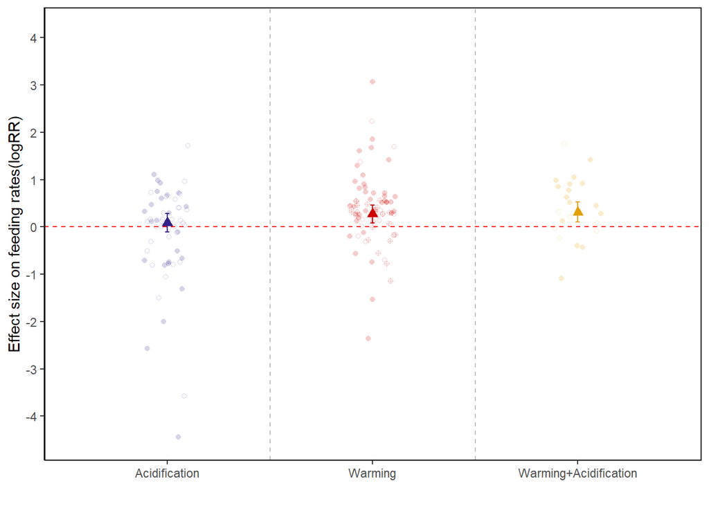

```r
P1<-ggplot()+
  theme_classic() +
  theme(panel.border = element_rect(colour = "black", fill=NA, size=0.7))+
    labs(x="", y="Effect size on feeding rates(logRR)")+
  geom_hline(yintercept=0, linetype="dashed",
                  color = "red", size=0.5)+
       geom_jitter(data=data, aes(x=Treatment, y=yi, color=Treatment, shape=Significance, group=Treatment), alpha = 0.2, position = position_jitterdodge(dodge.width=.5, jitter.width =0.9))+
  scale_shape_manual(values=c(16, 21, 10))+
  geom_point(data=new_variables_comp_2, aes(x=V1, y=estimate, color=V1), shape=17, size=2.5, position=position_dodge(width=.5))+
  geom_errorbar(data=new_variables_comp_2, aes(x=V1, color=V1, ymin=ci.ub, ymax=ci.lb), width=0.02, position=position_dodge(.5))+
  scale_fill_manual(values=colour.palette)+
  scale_color_manual(values=colour.palette)+
  scale_y_continuous(breaks = seq(-4,4, 1),limits = c(-4.5,4.2))+
  theme(legend.position = "none")+
  geom_vline(xintercept=c(1.5,2.5), linetype="dashed", size=0.4, color="gray")+guides(shape="none")

P1
```

Figure 2: Effect of stressor on predation rates

```r
png("Figures/Fig2_stressor.png", width=10, height=12, units="cm", res=300)
print(P1)
dev.off()
```

## Effect of stressor on predation rates by specific taxonomic group

```r
comp<-coef(summary(model6)) #get coeficients from model

comp<-setNames(cbind(rownames(comp), comp, row.names = NULL),
         c("COL1", "estimate", "se", "zval", "pval", "ci.lb", "ci.ub")) # set colnames

new_variables_comp<- gsub("Treatment|Tax_Group_specific","",comp$COL1)%>% str_split(":", simplify = TRUE)%>% as.data.frame() %>% cbind(comp) #Separate factors

new_variables_comp_2<- new_variables_comp %>%
  select(V1, V2, estimate, se, zval, pval, ci.lb, ci.ub) %>%
  group_by(V1) #group by factors

new_variables_comp_2<-as.data.frame(new_variables_comp_2) #make dataframe
```

Creating workbook with data from model considering stressor and taxonomic group specific

```r
write.xlsx(new_variables_comp_2, file = "Models.xlsx",
     sheetName = "Model_Stressors_TaxGroupSpec", append = TRUE)
```

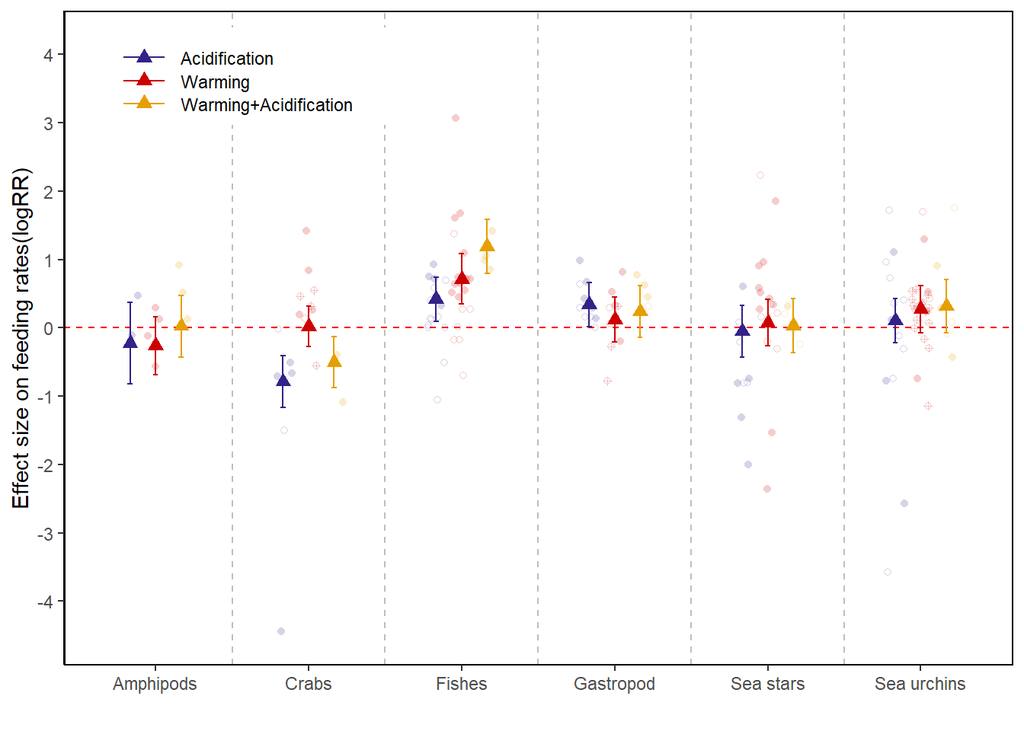

```r
P2<-ggplot()+
  theme_classic() +
  theme(panel.border = element_rect(colour = "black", fill=NA, size=0.7))+
    labs(x="", y="Effect size on feeding rates(logRR)", color = "Consumer")+
  geom_hline(yintercept=0, linetype="dashed",
                  color = "red", size=0.5)+
       geom_jitter(data=data, aes(x=Tax_Group_specific, y=yi, group=Treatment, color=Treatment, shape=Significance), alpha = 0.2, position = position_jitterdodge(dodge.width=.5, jitter.width =0.5))+
  scale_shape_manual(values=c(16, 21, 10))+
  geom_point(data=new_variables_comp_2, aes(x=V2, y=estimate, color=V1), shape=17, size=2.5, position=position_dodge(width=.5))+
  geom_errorbar(data=new_variables_comp_2, aes(x=V2, color=V1, ymin=ci.ub, ymax=ci.lb), width=0.1, position=position_dodge(.5))+
  scale_fill_manual(values=colour.palette)+
  scale_color_manual(values=colour.palette)+
  scale_y_continuous(breaks = seq(-4,4, 1),limits = c(-4.5,4.2))+
  theme(legend.position = c(.05, .90),
    legend.direction = "vertical",
    legend.box = "horizontal",
   legend.justification = c(.01, 0.5),
   legend.box.just = "left",
   #legend.margin = margin(4, 4, 4, 4),
  legend.margin =margin(r=40,l=5,t=5,b=5),
    legend.spacing.y = unit(0.15, "cm"),
      legend.text = element_text(size = 8.5, family = "Times New Roman"),
  legend.title=element_blank(),
   legend.key.size = unit(0.9, "cm"),
   legend.key.height = unit(0.4, "cm"))+
  geom_vline(xintercept=c(1.5,2.5,3.5, 4.5, 5.5), linetype="dashed", size=0.4, color="gray")+guides(shape="none")

P2
```

Figure 3: Effect of stressor on feeding rates by each specific taxonomic group

```r
png("Figures/Fig3_stressor_TaxGroup.png", width=18, height=12, units="cm", res=300)
print(P2)
dev.off()
```

## Effect of type of stressors on predation rates by general taxonomic group

```r
# Model considering only the stressor type model1
comp<-coef(summary(model7)) #get coeficients from model

comp<-setNames(cbind(rownames(comp), comp, row.names = NULL),
         c("COL1", "estimate", "se", "zval", "pval", "ci.lb", "ci.ub")) # set colnames

new_variables_comp<- gsub("Treatment|Tax_Group","",comp$COL1)%>% str_split(":", simplify = TRUE)%>% as.data.frame() %>% cbind(comp) #Separate factors

new_variables_comp_2<- new_variables_comp %>%
  select(V1, V2, estimate, se, zval, pval, ci.lb, ci.ub) %>%
  group_by(V1) #group by factors

new_variables_comp_2<-as.data.frame(new_variables_comp_2) #make dataframe
```

Creating workbook with data from model

```r
#Adding data from model considering only stressor
write.xlsx(new_variables_comp_2, file = "Models.xlsx",
   sheetName = "Model_Stressors_TaxGroup", append = TRUE)
```

Similarly lets plot

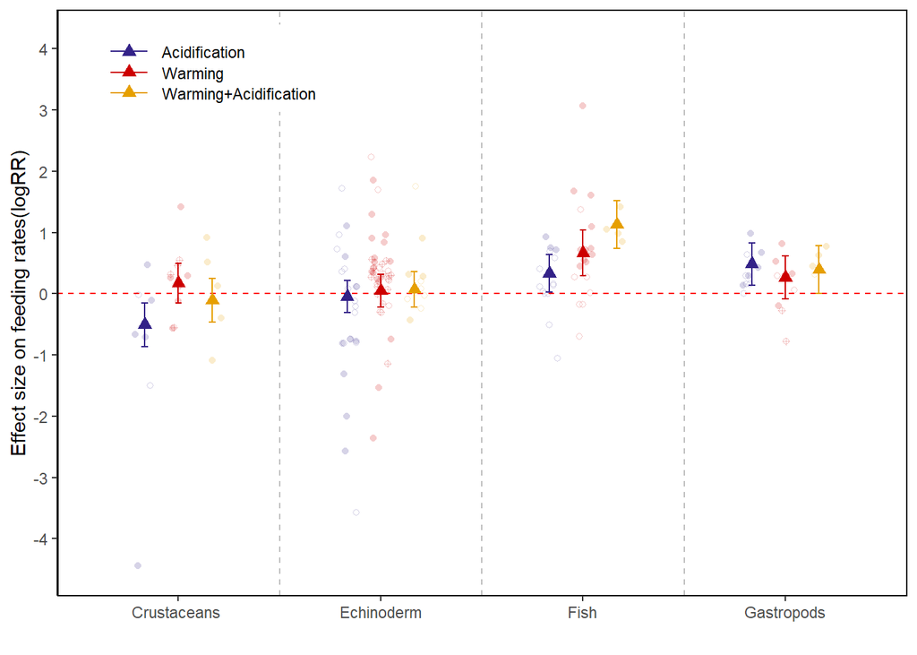

```r
P3<-ggplot()+
  theme_classic() +
  theme(panel.border = element_rect(colour = "black", fill=NA, size=0.7))+
    labs(x="", y="Effect size on feeding rates(logRR)")+
  geom_hline(yintercept=0, linetype="dashed",
                  color = "red", size=0.5)+
       geom_jitter(data=data, aes(x=Tax_Group, y=yi, color=Treatment, shape=Significance, group=Treatment), alpha = 0.2, position = position_jitterdodge(dodge.width=.5, jitter.width =0.4))+
  scale_shape_manual(values=c(16, 21, 10))+
  geom_point(data=new_variables_comp_2, aes(x=V2, y=estimate, color=V1), shape=17, size=2.5, position=position_dodge(width=.5))+
  geom_errorbar(data=new_variables_comp_2, aes(x=V2, color=V1, ymin=ci.ub, ymax=ci.lb), width=0.1, position=position_dodge(.5))+
  scale_fill_manual(values=colour.palette)+
  scale_color_manual(values=colour.palette)+
  scale_y_continuous(breaks = seq(-4,4, 1),limits = c(-4.5,4.2))+
  theme(legend.position = "none")+
  geom_vline(xintercept=c(1.5,2.5, 3.5), linetype="dashed", size=0.4, color="gray")+guides(shape="none")+
  theme(legend.position = c(.05, .90),
    legend.direction = "vertical",
    legend.box = "horizontal",
   legend.justification = c(.01, 0.5),
   legend.box.just = "left",
   #legend.margin = margin(4, 4, 4, 4),
  legend.margin =margin(r=40,l=5,t=5,b=5),
    legend.spacing.y = unit(0.15, "cm"),
      legend.text = element_text(size = 8.5, family = "Times New Roman"),
  legend.title=element_blank(),
   legend.key.size = unit(0.9, "cm"),
   legend.key.height = unit(0.4, "cm"))

P3
```

Figure T2: Effect of stressor on predation rates by general taxonomic group

```r
png("Figures/Fig3_stressor_GenTaxGroup.png", width=15, height=12, units="cm", res=300)
print(P3)
dev.off()
```

## Effect of experimental factors on temperature experiments

```r
data_TempSig<-data %>%
  filter(Treatment=="Warming") %>% # %>%
 filter(!Cons_Aclimatation=="NR")%>% #removing experiments don't report aclimatation
 filter(!Exp_duration=="NR") #filtering experiments don't report days duration



# Lets model which element determine effect of warming on feeding rates
model_t2<- rma.mv(yi,vi, mods =~Temp_variation+Exp_duration_days
+ExpTreatment+Cons_Aclimatation_days+Starvation, random=~1|Title,  method = "REML", knha=TRUE, data = data_TempSig)
summary(model_t2)
```

```
##
## Multivariate Meta-Analysis Model (k = 65; method: REML)
##
##   logLik  Deviance       AIC       BIC      AICc
## -81.1934  162.3868  176.3868  190.9295  178.5829
##
## Variance Components:
##
##             estim    sqrt  nlvls  fixed  factor
## sigma^2    0.3651  0.6043     21     no   Title
##
## Test for Residual Heterogeneity:
## QE(df = 59) = 247.1138, p-val < .0001
##
## Test of Moderators (coefficients 2:6):
## QM(df = 5) = 16.2847, p-val = 0.0061
##
## Model Results:
##
##                         estimate      se     zval    pval    ci.lb   ci.ub
## intrcpt                  -0.0491  0.2964  -0.1657  0.8684  -0.6300  0.5318
## Temp_variation            0.0503  0.0131   3.8567  0.0001   0.0248  0.0759  ***
## Exp_duration_days        -0.0009  0.0028  -0.3147  0.7530  -0.0063  0.0045
## ExpTreatmentConsumer      0.2908  0.3035   0.9581  0.3380  -0.3041  0.8856
## Cons_Aclimatation_days    0.0001  0.0025   0.0274  0.9781  -0.0049  0.0051
## StarvationYes            -0.0363  0.3630  -0.1000  0.9204  -0.7477  0.6751
##
## ---
## Signif. codes:  0 '***' 0.001 '**' 0.01 '*' 0.05 '.' 0.1 ' ' 1
```

```r
model_t1<- rma.mv(yi,vi, mods =~Temp_variation, random=~1|Title,  method = "REML", knha=TRUE, data = data_TempSig)
summary(model_t1)
```

```
##
## Multivariate Meta-Analysis Model (k = 65; method: REML)
##
##   logLik  Deviance       AIC       BIC      AICc
## -85.3763  170.7527  176.7527  183.1821  177.1595
##
## Variance Components:
##
##             estim    sqrt  nlvls  fixed  factor
## sigma^2    0.2990  0.5468     21     no   Title
##
## Test for Residual Heterogeneity:
## QE(df = 63) = 291.8341, p-val < .0001
##
## Test of Moderators (coefficient 2):
## QM(df = 1) = 15.6248, p-val < .0001
##
## Model Results:
##
##                 estimate      se    zval    pval    ci.lb   ci.ub
## intrcpt           0.0570  0.1496  0.3813  0.7030  -0.2362  0.3503
## Temp_variation    0.0511  0.0129  3.9528  <.0001   0.0257  0.0764  ***
##
## ---
## Signif. codes:  0 '***' 0.001 '**' 0.01 '*' 0.05 '.' 0.1 ' ' 1
```

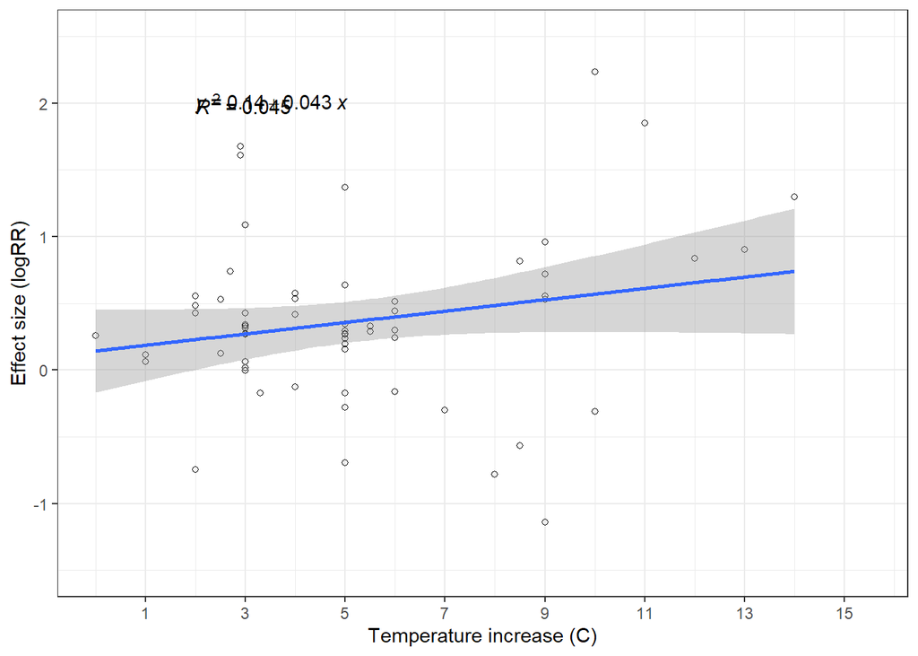

```r
#now lets plot a correlation temperature and effect
ggplot(data=data_TempSig, aes(x=Temp_variation, y=yi))+
  geom_point(shape=21)+
  geom_smooth(method=lm, formula=y~x)+
  theme_bw()+
  ylab("Effect size (logRR)")+xlab("Temperature increase (C)")+
  #scale_shape_manual(values=c(16, 21, 8))+
scale_y_continuous(breaks = seq(-1,2, 1),limits = c(-1.5, 2.5))+
scale_x_continuous(breaks = seq(1,15,2),limits = c(0, 15.5))+
    stat_regline_equation(label.x=2, label.y=2) +
        stat_cor(aes(label=..rr.label..), label.x=2, label.y=2)
```

The increase in temperature seems to have a direct effect on the normalize effect size. It is the only experimental factor that had an effect

Creating excel file with model’s results

```r
comp<-coef(summary(model_t2)) #get coeficients from model

comp<-setNames(cbind(rownames(comp), comp, row.names = NULL),
         c("Variable", "estimate", "se", "zval", "pval", "ci.lb", "ci.ub")) # set colnames

new_variables_comp_2<-as.data.frame(comp) #make dataframe
```

Creating workbook with data from model explaining experimental variables affecing warming experiments

```r
write.xlsx(new_variables_comp_2, file = "Models.xlsx",
    sheetName = "Model_ExpVar_Warming", append = TRUE)
```

## Effect of methodological factors the effect acidification on feeding rates

```r
data_a<-data %>%
  filter(Treatment=="Acidification")

model_a_only<- rma.mv(yi,vi, mods =~pH_var, random=~1|Title,  method = "REML", knha=TRUE, data = data_a)
summary(model_a_only)
```

```
##
## Multivariate Meta-Analysis Model (k = 48; method: REML)
##
##    logLik   Deviance        AIC        BIC       AICc
## -171.4165   342.8331   348.8331   354.3190   349.4045
##
## Variance Components:
##
##             estim    sqrt  nlvls  fixed  factor
## sigma^2    0.2229  0.4722     21     no   Title
##
## Test for Residual Heterogeneity:
## QE(df = 46) = 749.3535, p-val < .0001
##
## Test of Moderators (coefficient 2):
## QM(df = 1) = 33.1413, p-val < .0001
##
## Model Results:
##
##          estimate      se     zval    pval    ci.lb   ci.ub
## intrcpt   -0.0939  0.1195  -0.7860  0.4318  -0.3282  0.1403
## pH_var     0.3549  0.0616   5.7568  <.0001   0.2340  0.4757  ***
##
## ---
## Signif. codes:  0 '***' 0.001 '**' 0.01 '*' 0.05 '.' 0.1 ' ' 1
```

```r
data_AcidSig<-data %>%
  filter(Treatment=="Acidification")%>%
  #filter(Significance=="Significant")%>%
  filter(Acidif_Measure=="pH")%>% #lets use pH as most studies use pH compare to pCO2
  filter(!Cons_Aclimatation=="NR")%>%
  filter(!Exp_duration=="NR") #filtering experiments don't report days duration


#Lets model effect of experimetnal variables
model_a1<- rma.mv(yi,vi, mods =~pH_var+Exp_duration_days
+ExpTreatment+Exp_duration_days +ExpTreatment+Cons_Aclimatation_days +Starvation, random=~1|Title,  method = "REML", knha=TRUE, data = data_AcidSig)
summary(model_a1)
```

```
##
## Multivariate Meta-Analysis Model (k = 14; method: REML)
##
##   logLik  Deviance       AIC       BIC      AICc
## -13.5251   27.0502   41.0502   41.6063  153.0502
##
## Variance Components:
##
##             estim    sqrt  nlvls  fixed  factor
## sigma^2    0.0000  0.0000      7     no   Title
##
## Test for Residual Heterogeneity:
## QE(df = 8) = 17.0366, p-val = 0.0297
##
## Test of Moderators (coefficients 2:6):
## QM(df = 5) = 14.2024, p-val = 0.0144
##
## Model Results:
##
##                         estimate      se     zval    pval    ci.lb   ci.ub
## intrcpt                  -0.1469  0.2653  -0.5538  0.5797  -0.6669  0.3731
## pH_var                    0.6871  0.8716   0.7883  0.4305  -1.0212  2.3955
## Exp_duration_days         0.0130  0.0256   0.5065  0.6125  -0.0372  0.0632
## ExpTreatmentConsumer     -2.3112  1.2592  -1.8354  0.0664  -4.7791  0.1568   .
## Cons_Aclimatation_days    0.0051  0.0017   3.0053  0.0027   0.0018  0.0084  **
## StarvationYes             0.3774  0.2321   1.6257  0.1040  -0.0776  0.8323
##
## ---
## Signif. codes:  0 '***' 0.001 '**' 0.01 '*' 0.05 '.' 0.1 ' ' 1
```

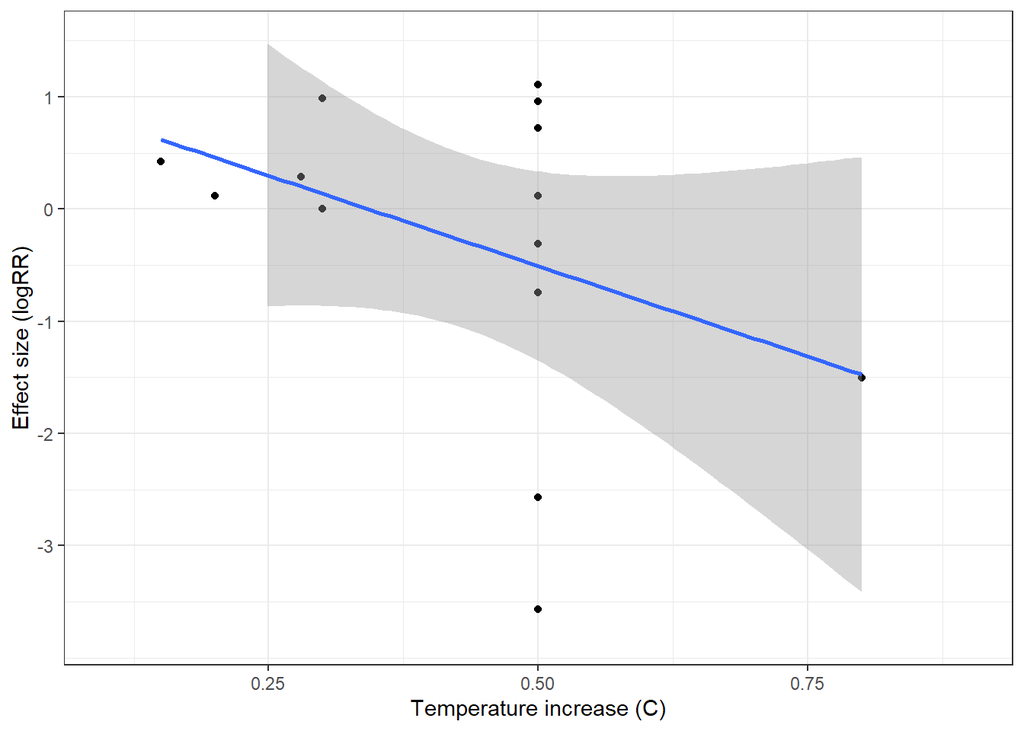

```r
#Trying to plot ph variation vs effect
ggplot(data=data_AcidSig, aes(x=pH_var, y=yi))+geom_point()+geom_smooth(method=lm, formula = y~x)+theme_bw()+
 ylab("Effect size (logRR)")+
xlab("Temperature increase (C)")+
scale_y_continuous(breaks = seq(-3, 2, 1),limits = c(-3.8, 1.5))+
scale_x_continuous(breaks = seq(0 ,1, 0.25),limits = c(0.1, 0.9))
```

Creating excel file with model’s results

```r
comp<-coef(summary(model_a1)) #get coeficients from model

comp<-setNames(cbind(rownames(comp), comp, row.names = NULL),
         c("Variable", "estimate", "se", "zval", "pval", "ci.lb", "ci.ub")) # set colnames

new_variables_comp_2<-as.data.frame(comp) #make dataframe
```

Creating workbook with data from model explaining experimental variables affecing acidification experiments

```r
write.xlsx(new_variables_comp_2, file = "Models.xlsx",
    sheetName = "Model_ExpVar_Acidification", append = TRUE)
```

## Effect of methodological factors the effect acidification+ warming on feeding rates

```r
data_Temp_Acidif<-data %>%
  filter(Treatment=="Warming+Acidification")

model_acid_warming<- rma.mv(yi,vi, mods =~pH_var+Temp_variation +Exp_duration_days+ExpTreatment+Exp_duration_days +ExpTreatment+Cons_Aclimatation_days+Starvation, random=~1|Title,  method = "REML", knha=TRUE, data = data_Temp_Acidif)
summary(model_acid_warming)
```

```
##
## Multivariate Meta-Analysis Model (k = 13; method: REML)
##
##   logLik  Deviance       AIC       BIC      AICc
##  -5.8102   11.6204   29.6204   26.1053  209.6204
##
## Variance Components:
##
##             estim    sqrt  nlvls  fixed  factor
## sigma^2    0.4873  0.6980      8     no   Title
##
## Test for Residual Heterogeneity:
## QE(df = 5) = 36.0633, p-val < .0001
##
## Test of Moderators (coefficients 2:8):
## QM(df = 7) = 7.8174, p-val = 0.3490
##
## Model Results:
##
##                         estimate      se     zval    pval    ci.lb   ci.ub
## intrcpt                  -0.4303  0.5676  -0.7582  0.4484  -1.5428  0.6821
## pH_var                    2.0335  0.8628   2.3569  0.0184   0.3425  3.7245  *
## Temp_variation           -0.0147  0.0875  -0.1675  0.8670  -0.1862  0.1569
## Exp_duration_days         0.0066  0.0174   0.3781  0.7054  -0.0275  0.0407
## ExpTreatmentConsumer     -2.7046  1.6528  -1.6363  0.1018  -5.9441  0.5349
## ExpTreatmentPrey          0.4550  1.1038   0.4122  0.6802  -1.7084  2.6184
## Cons_Aclimatation_days    0.0023  0.0075   0.3035  0.7615  -0.0125  0.0171
## StarvationYes             0.4112  0.8104   0.5074  0.6119  -1.1771  1.9995
##
## ---
## Signif. codes:  0 '***' 0.001 '**' 0.01 '*' 0.05 '.' 0.1 ' ' 1
```

Creating excel file with model’s results

```r
comp<-coef(summary(model_acid_warming)) #get coeficients from model

comp<-setNames(cbind(rownames(comp), comp, row.names = NULL),
         c("Variable", "estimate", "se", "zval", "pval", "ci.lb", "ci.ub")) # set colnames

new_variables_comp_2<-as.data.frame(comp) #make dataframe
```

Writing the data into excel spreedsheet

```r
write.xlsx(new_variables_comp_2, file = "Models.xlsx",
    sheetName = "Model_acidf_warm", append = TRUE)
```

## Map with location of studies

```r
world <- ne_countries(scale = "medium", returnclass = "sf")
```

```r
studies<-data %>%
  select(Title, Treatment, Longitude, Latitude)%>%
  group_by(Treatment, Longitude, Latitude)%>%
  distinct(Title)

str(studies)
```

[output not shown]

[output cut: 17 more lines]

[output not shown]

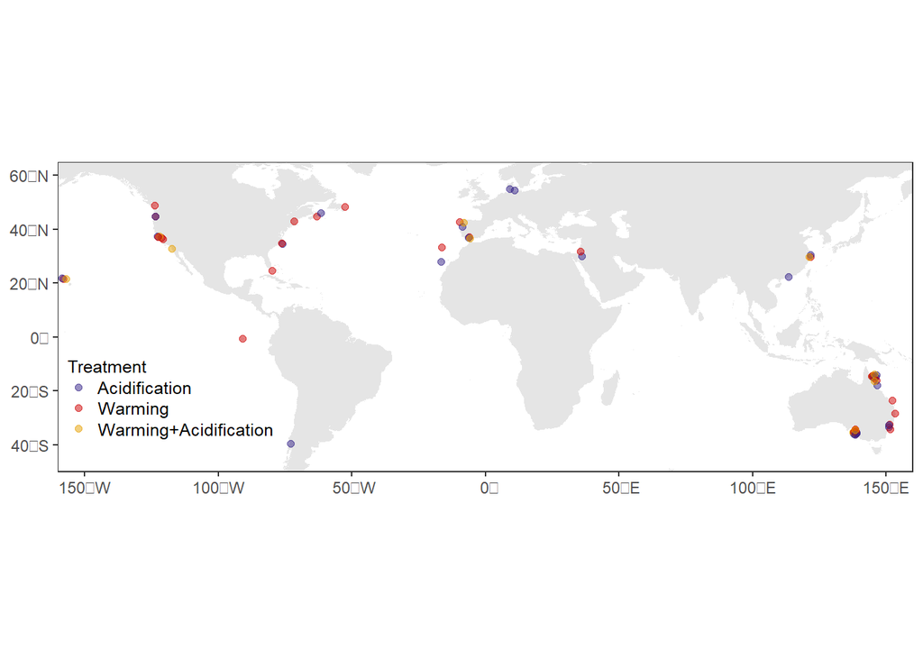

```r
MapStudies<-
  ggplot(data = world)+
  geom_sf(color=NA)+
  #let's limit the map area
  coord_sf(xlim = c(-160, 160), ylim = c(-50, 65), expand = FALSE)+
theme_bw()+
  theme(axis.title.x=element_blank(),axis.title.y=element_blank(), panel.grid.major = element_line(colour = "white"))+
   geom_point(data=studies, aes(x=Longitude, y=Latitude, colour=Treatment), alpha = 0.5, size=1.6, position = position_jitter(w=1, h=1))+
  scale_colour_manual(values=colour.palette)+
  theme(legend.position = c(.01, .10),
    legend.direction = "vertical",
    legend.justification = c("left", "bottom"),
    legend.box.just = "left",
    legend.margin = margin(1, 1, 1, 1),
    legend.spacing.y = unit(0.05, "cm"),
      legend.text = element_text(size = 9.5, family = "Arial"),
  legend.title=element_text(size=9.2, family = "Arial"),
   legend.key.size = unit(0.4, "cm"),
      legend.key.height = unit(0.4, "cm"))+
  guides(fill = guide_legend(override.aes = list(shape = 21)))

MapStudies
```

Figure 1: Map with location of studies

```r
png("Figures/Fig1_Map.png", width=18, height=12, units="cm", res=300)
print(MapStudies)
dev.off()
```